# Projeto II Nanodegree Fundamentos de Data Science I

# Overview

## Nanodegree

Os cursos Nanodegree são formações online com menor tempo de duração se comparados aos programas tradicionais oferecidos pelas instituições de ensino superior tradicionais.Eles se caracterizaram como uma formação a distância, de duração curta a média e que faz uso de ferramentas como mentoria de especialistas na área, realização de projetos práticos e feedbacks personalizados a cada entrega.

## Data Science

Ciência de dados (em inglês: data science) é uma área interdisciplinar voltada para o estudo e a análise de dados, estruturados ou não, que visa a extração de conhecimento ou insights para possíveis tomadas de decisão, de maneira similar à mineração de dados. Ciência de dados alia big data e machine learning, além de técnicas de outras áreas interdisciplinares como estatística, economia, engenharia e outros subcampos da computação como: banco de dados e análise de agrupamentos (cluster analysis).

# Titanic - Data Science from Disaster

## Introdução

O naufrágio do RMS Titanic ocorreu entre a noite de 14 de abril até à manhã de 15 de abril de 1912 no Atlântico Norte, quatro dias após o início da viagem inaugural do navio que partiu de Southampton com destino à cidade de Nova Iorque. O maior navio de passageiros em serviço à época, o Titanic tinha estimadas 2.224 pessoas a bordo quando atingiu um iceberg por volta de 23:40 (horário no navio) no domingo, 14 de abril de 1912. O afundamento aconteceu duas horas e quarenta minutos depois, às 02:20 (05:18 GMT) na segunda-feira, 15 de abril, resultando na morte de mais de 1.500 pessoas, transformando-o em um dos desastres marítimos mais mortais.

## Informações sobre o projeto

Este estudo tem como objetivo identificar o fator de sobrevivência de alguns passageiros após o naufragio do Titanic através de técnicas de Análise de Dados. O arquivo disponibilizado contém dados demográficos e informações de 891 dos 2.224 passageiros e tripulantes a bordo do Titanic.  
Análise elaborada por **Samarone N. da Silva** como projeto final do curso Nanodegree Fundamentos de Data Science I da [Udacity](https://www.udacity.com).  
Dataset obtido em [Kaggle.com](https://www.kaggle.com/c/titanic/data). Campos não relevantes foram removidos do arquivo original para obter uma melhor análise.  
Relação das fontes de pesquisa:  
https://www.udacity.com/course/data-scientist-nanodegree--nd025  
https://www.kaggle.com/c/titanic  
https://pt.wikipedia.org/wiki/Naufr%C3%A1gio_do_RMS_Titanic

- **Importando as bibliotecas necessárias para análise dos dados**

```python
import pandas as pd
import numpy as np
import matplotlib.pyplot as plt
```

- **Convertendo o arquivo csv em um Data Frame através da bibliotecas Pandas**

```python
df = pd.read_csv('titanic-data-6.csv', delimiter=',')
```

### Variáveis

Survived (Sobreviveu): 0 = Não, 1 = Sim  
Pclass (Classe): Classe de ingresso 1 = Superior, 2 = Meio, 3 = Inferior  
Sex (Sexo): Sexo do passageiro  
Age (Idade): Idade em anos  
Sibsp: Quantidade de irmãos / cônjuges a bordo do Titanic  
Parch: Quantidade de pais / crianças a bordo do Titanic  
Embarked (Embarque): Porto de Embarque (C = Cherbourg, Q = Queenstown, S = Southampton)

- **Identificando o Data Frame**

```python
print('Total de linhas = ',df.shape[0])
print('Total de colunas = ',df.shape[1])
```

```
Total de linhas =  891
Total de colunas =  12
```

- **Exibindo as cinco primeiras linhas do Data Frame**

```python
df.head()
```

|  | PassengerId | Survived | Pclass | Name | Sex | Age | SibSp | Parch | Ticket | Fare | Cabin | Embarked |
| --- | --- | --- | --- | --- | --- | --- | --- | --- | --- | --- | --- | --- |
| 0 | 1 | 0 | 3 | Braund, Mr. Owen Harris | male | 22.0 | 1 | 0 | A/5 21171 | 7.2500 | NaN | S |
| 1 | 2 | 1 | 1 | Cumings, Mrs. John Bradley (Florence Briggs Th... | female | 38.0 | 1 | 0 | PC 17599 | 71.2833 | C85 | C |
| 2 | 3 | 1 | 3 | Heikkinen, Miss. Laina | female | 26.0 | 0 | 0 | STON/O2. 3101282 | 7.9250 | NaN | S |
| 3 | 4 | 1 | 1 | Futrelle, Mrs. Jacques Heath (Lily May Peel) | female | 35.0 | 1 | 0 | 113803 | 53.1000 | C123 | S |
| 4 | 5 | 0 | 3 | Allen, Mr. William Henry | male | 35.0 | 0 | 0 | 373450 | 8.0500 | NaN | S |

- **Removendo colunas não relevantes para o projeto**

```python
#Função para remover colunas não utilizadas
#param: Colunas a serem removidas

def remove(colunas):
    for i in range(0, len(colunas)):
        df.drop([colunas[i]],axis = 1, inplace = True)
    return df.head()

colunas = ['Fare','Ticket','Cabin']
remove(colunas)
```

|  | PassengerId | Survived | Pclass | Name | Sex | Age | SibSp | Parch | Embarked |
| --- | --- | --- | --- | --- | --- | --- | --- | --- | --- |
| 0 | 1 | 0 | 3 | Braund, Mr. Owen Harris | male | 22.0 | 1 | 0 | S |
| 1 | 2 | 1 | 1 | Cumings, Mrs. John Bradley (Florence Briggs Th... | female | 38.0 | 1 | 0 | C |
| 2 | 3 | 1 | 3 | Heikkinen, Miss. Laina | female | 26.0 | 0 | 0 | S |
| 3 | 4 | 1 | 1 | Futrelle, Mrs. Jacques Heath (Lily May Peel) | female | 35.0 | 1 | 0 | S |
| 4 | 5 | 0 | 3 | Allen, Mr. William Henry | male | 35.0 | 0 | 0 | S |

- **Renomeando os locais de embarcação**

```python
df['Embarked'] = df['Embarked'].replace(['S','Q','C'],['Southampton','Queenstown','Cherbourg'])
```

- **Exibindo as cinco ultimas linhas do DataFrame**

```python
df.tail()
```

|  | PassengerId | Survived | Pclass | Name | Sex | Age | SibSp | Parch | Embarked |
| --- | --- | --- | --- | --- | --- | --- | --- | --- | --- |
| 886 | 887 | 0 | 2 | Montvila, Rev. Juozas | male | 27.0 | 0 | 0 | Southampton |
| 887 | 888 | 1 | 1 | Graham, Miss. Margaret Edith | female | 19.0 | 0 | 0 | Southampton |
| 888 | 889 | 0 | 3 | Johnston, Miss. Catherine Helen "Carrie" | female | NaN | 1 | 2 | Southampton |
| 889 | 890 | 1 | 1 | Behr, Mr. Karl Howell | male | 26.0 | 0 | 0 | Cherbourg |
| 890 | 891 | 0 | 3 | Dooley, Mr. Patrick | male | 32.0 | 0 | 0 | Queenstown |

- **Gerando uma amostra aleatória do DataFrame**

```python
df.sample(20)
```

|  | PassengerId | Survived | Pclass | Name | Sex | Age | SibSp | Parch | Embarked |
| --- | --- | --- | --- | --- | --- | --- | --- | --- | --- |
| 640 | 641 | 0 | 3 | Jensen, Mr. Hans Peder | male | 20.0 | 0 | 0 | Southampton |
| 609 | 610 | 1 | 1 | Shutes, Miss. Elizabeth W | female | 40.0 | 0 | 0 | Southampton |
| 455 | 456 | 1 | 3 | Jalsevac, Mr. Ivan | male | 29.0 | 0 | 0 | Cherbourg |
| 79 | 80 | 1 | 3 | Dowdell, Miss. Elizabeth | female | 30.0 | 0 | 0 | Southampton |
| 595 | 596 | 0 | 3 | Van Impe, Mr. Jean Baptiste | male | 36.0 | 1 | 1 | Southampton |
| 198 | 199 | 1 | 3 | Madigan, Miss. Margaret "Maggie" | female | NaN | 0 | 0 | Queenstown |
| 371 | 372 | 0 | 3 | Wiklund, Mr. Jakob Alfred | male | 18.0 | 1 | 0 | Southampton |
| 588 | 589 | 0 | 3 | Gilinski, Mr. Eliezer | male | 22.0 | 0 | 0 | Southampton |
| 742 | 743 | 1 | 1 | Ryerson, Miss. Susan Parker "Suzette" | female | 21.0 | 2 | 2 | Cherbourg |
| 573 | 574 | 1 | 3 | Kelly, Miss. Mary | female | NaN | 0 | 0 | Queenstown |
| 445 | 446 | 1 | 1 | Dodge, Master. Washington | male | 4.0 | 0 | 2 | Southampton |
| 172 | 173 | 1 | 3 | Johnson, Miss. Eleanor Ileen | female | 1.0 | 1 | 1 | Southampton |
| 413 | 414 | 0 | 2 | Cunningham, Mr. Alfred Fleming | male | NaN | 0 | 0 | Southampton |
| 388 | 389 | 0 | 3 | Sadlier, Mr. Matthew | male | NaN | 0 | 0 | Queenstown |
| 729 | 730 | 0 | 3 | Ilmakangas, Miss. Pieta Sofia | female | 25.0 | 1 | 0 | Southampton |
| 753 | 754 | 0 | 3 | Jonkoff, Mr. Lalio | male | 23.0 | 0 | 0 | Southampton |
| 325 | 326 | 1 | 1 | Young, Miss. Marie Grice | female | 36.0 | 0 | 0 | Cherbourg |
| 225 | 226 | 0 | 3 | Berglund, Mr. Karl Ivar Sven | male | 22.0 | 0 | 0 | Southampton |
| 492 | 493 | 0 | 1 | Molson, Mr. Harry Markland | male | 55.0 | 0 | 0 | Southampton |
| 80 | 81 | 0 | 3 | Waelens, Mr. Achille | male | 22.0 | 0 | 0 | Southampton |

Algumas linhas da coluna idade estão com valores nulos.

- **Total de registros no arquivo**

```python
len(df)
```

```
891
```

## Limpeza de Dados

No campo idade contem diversos valores não numéricos(NaN), esses serão substituidos por zero para uma maior legibilidade de visualização onde zero representa idade não informada.

```python
df['Age'].fillna(0, inplace = True)
df.head(20)
```

|  | PassengerId | Survived | Pclass | Name | Sex | Age | SibSp | Parch | Embarked |
| --- | --- | --- | --- | --- | --- | --- | --- | --- | --- |
| 0 | 1 | 0 | 3 | Braund, Mr. Owen Harris | male | 22.0 | 1 | 0 | Southampton |
| 1 | 2 | 1 | 1 | Cumings, Mrs. John Bradley (Florence Briggs Th... | female | 38.0 | 1 | 0 | Cherbourg |
| 2 | 3 | 1 | 3 | Heikkinen, Miss. Laina | female | 26.0 | 0 | 0 | Southampton |
| 3 | 4 | 1 | 1 | Futrelle, Mrs. Jacques Heath (Lily May Peel) | female | 35.0 | 1 | 0 | Southampton |
| 4 | 5 | 0 | 3 | Allen, Mr. William Henry | male | 35.0 | 0 | 0 | Southampton |
| 5 | 6 | 0 | 3 | Moran, Mr. James | male | 0.0 | 0 | 0 | Queenstown |
| 6 | 7 | 0 | 1 | McCarthy, Mr. Timothy J | male | 54.0 | 0 | 0 | Southampton |
| 7 | 8 | 0 | 3 | Palsson, Master. Gosta Leonard | male | 2.0 | 3 | 1 | Southampton |
| 8 | 9 | 1 | 3 | Johnson, Mrs. Oscar W (Elisabeth Vilhelmina Berg) | female | 27.0 | 0 | 2 | Southampton |
| 9 | 10 | 1 | 2 | Nasser, Mrs. Nicholas (Adele Achem) | female | 14.0 | 1 | 0 | Cherbourg |
| 10 | 11 | 1 | 3 | Sandstrom, Miss. Marguerite Rut | female | 4.0 | 1 | 1 | Southampton |
| 11 | 12 | 1 | 1 | Bonnell, Miss. Elizabeth | female | 58.0 | 0 | 0 | Southampton |
| 12 | 13 | 0 | 3 | Saundercock, Mr. William Henry | male | 20.0 | 0 | 0 | Southampton |
| 13 | 14 | 0 | 3 | Andersson, Mr. Anders Johan | male | 39.0 | 1 | 5 | Southampton |
| 14 | 15 | 0 | 3 | Vestrom, Miss. Hulda Amanda Adolfina | female | 14.0 | 0 | 0 | Southampton |
| 15 | 16 | 1 | 2 | Hewlett, Mrs. (Mary D Kingcome) | female | 55.0 | 0 | 0 | Southampton |
| 16 | 17 | 0 | 3 | Rice, Master. Eugene | male | 2.0 | 4 | 1 | Queenstown |
| 17 | 18 | 1 | 2 | Williams, Mr. Charles Eugene | male | 0.0 | 0 | 0 | Southampton |
| 18 | 19 | 0 | 3 | Vander Planke, Mrs. Julius (Emelia Maria Vande... | female | 31.0 | 1 | 0 | Southampton |
| 19 | 20 | 1 | 3 | Masselmani, Mrs. Fatima | female | 0.0 | 0 | 0 | Cherbourg |

## Algumas perguntas sobre os dados

## **1 - Quantos passageiros havia em cada classe do navio?**

```python
df["Pclass"].value_counts()
```

```
3    491
1    216
2    184
Name: Pclass, dtype: int64
```

```
Text(0,0.5,'Classe')
```

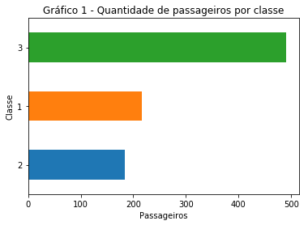

```python
df["Pclass"].value_counts(ascending=True).plot.barh(title="Gráfico 1 - Quantidade de passageiros por classe")
plt.xlabel('Passageiros')
plt.ylabel('Classe')
```

A maioria dos passageiros ocupavam a classe mais inferior do Navio com isso acreditasse que a o ocupação da classe superior tenha sido mais limitada.

## **2 - Quantas mulheres havia a bordo do navio?**

```python
len(df[df.Sex=='female'])
```

```
314
```

## **3 - Quantos homens havia a bordo do navio?**

```python
len(df[df.Sex=="male"])
```

```
577
```

Dos 891 passageiros 577 eram do sexo masculino entre crianças, adultos e idosos.

## **4 - Quantidade de sobreviventes e não sobreviventes?**

```python
print('Sobreviveram     :', df['Survived'].value_counts()[1])
print('Não sobreviveram :', df['Survived'].value_counts()[0])
```

```
Sobreviveram     : 342
Não sobreviveram : 549
```

```
Text(0,0.5,'')
```

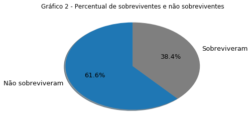

```python
df['Survived'].value_counts().plot.pie(colors=('tab:blue', 'tab:gray'),
                                       title='Gráfico 2 - Percentual de sobreviventes e não sobreviventes',
                                       fontsize=13, shadow=True, startangle=90, autopct='%1.1f%%',
                                       labels=('Não sobreviveram','Sobreviveram'),
                                       figsize=(6,4)).set_ylabel('')
```

Apenas 38% dos passegeiros sobreviveram.

## **4 - Quantidade de sobreviventes por classe?**

```
Text(0.5,1,'Gráfico 3. Quantidade de sobreviventes por Classe')
```

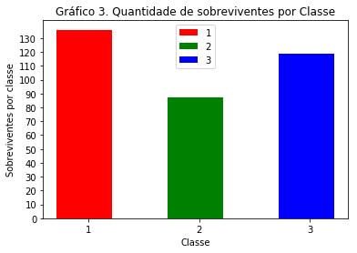

```python
N = 3
f_class = df.query('Survived == 1').groupby('Pclass')['Survived'].count()[1]
s_class = df.query('Survived == 1').groupby('Pclass')['Survived'].count()[2]
t_class = df.query('Survived == 1').groupby('Pclass')['Survived'].count()[3]
ind = np.arange(N)
width = 0.5

fig, ax = plt.subplots()
p1 = ax.bar(ind, [f_class, s_class, t_class], width, color=['r', 'g', 'b'])
ax.set_xticks(ind + width/15.)
ax.set_yticks(np.arange(0, max((f_class, s_class, t_class)), 10))
ax.set_xticklabels(('1', '2', '3'))
plt.legend((p1[0], p1[1], p1[2]), ('1', '2', '3'));
plt.xlabel('Classe')
plt.ylabel('Sobreviventes por classe')
plt.title('Gráfico 3. Quantidade de sobreviventes por Classe')
```

## **5 - Qual cidade embarcaram mais passageiros?**

```
Text(0,0.5,'')
```

[figure not shown]

```python
df['Embarked'].value_counts().plot.pie(colors=('tab:blue', 'tab:gray', 'tab:orange'),
                                       title='Gráfico 4 - Percentual de local de embarcação',
                                       fontsize=13, shadow=True, startangle=90, autopct='%1.1f%%',
                                       labels=('Southampton','Queenstown','Cherbourg'),
                                       figsize=(6,4)).set_ylabel('')
```

A maioria dos passageiros embarcaram em Southampton, esta local é considerado a maior cidade portuaria do Reino Unido. A outra minoria embarcou na Nova Zelandia e França.

## Limitações

O arquivo original continha valores não numéricos no campo idade, com isso não foi possivel obter uma precisão sobre a média de idade dos passagereiros.

- Medida tomada:

Esses valores foram substituidos por zero apenas para melhor legibilidade na visualização dos dados.

- Após o replace dos valores não numéricos as informações ficaram mais legiveis.

## Ferramentas e bibliotecas que foram utilizadas

[figure not shown]